[figure not shown]

[Coastal barometer website](http://folk.ntnu.no/erlenfau/KystBaro/) | [Coastal barometer blog](https://kystbarometeret.com) | [Ocean health index](http://www.oceanhealthindex.org) | [Citation policy](http://ohi-science.org/citation-policy/)

# Total aquaculture production

Compiled on Fri Nov 8 16:16:30 2019 by marinaespinasse

```r
knitr::opts_chunk$set(message = FALSE, warning= FALSE, message = FALSE)
source('~/github/nor-prep/prep/src/common.R')
```

```r
library(ggthemes)
library(janitor)
library(DT)
```

# 1 Loading aquaculture produciton data: total biomass produced, feed used, and biomass change per month.

```r
biomass_0518 <-read.csv(file.path(dir_M[2],"Aquaculture/Production/production_unlocked_concatenated_2005_2018/akva_biomass_2005_2018_formatted.csv"))
feed_0518 <-read.csv(file.path(dir_M[2],"Aquaculture/Production/production_unlocked_concatenated_2005_2018/akva_feed_2005_2018_formatted.csv"))
tap_0518 <-read.csv(file.path(dir_M[2],"Aquaculture/Production/production_unlocked_concatenated_2005_2018/akva_tap_formatted_2005_2018.csv"))
uttak_0518 <-read.csv(file.path(dir_M[2],"Aquaculture/Production/production_unlocked_concatenated_2005_2018/akva_uttak_2005_2018_formatted.csv"))
"/Volumes/ftp.imr.no/Aquaculture/Production/production_unlocked_concatenated_2005_2018/akva_biomass_2005_2018_formatted.csv"
```

```
## [1] "/Volumes/ftp.imr.no/Aquaculture/Production/production_unlocked_concatenated_2005_2018/akva_biomass_2005_2018_formatted.csv"
```

```r
municip <- read.table("../../administrative/komlist.csv", header = TRUE, sep = ";")
```

# 2 Cleaning and formatting the data

## 2.1 Pre-clean standing biomass table

```r
biomass_prep <- biomass_0518 %>%
  clean_names() %>%
  rename(year = aar) %>%
  mutate(biomchange_salmon = (laks_des_beh_kg-laks_jan_beh_kg)) %>%
  mutate(biomchange_trout = (regnb_des_beh_kg-regnb_jan_beh_kg)) %>%
  select(c(year,kommunenr,kommune,biomchange_salmon, biomchange_trout)) %>%
  left_join(municip[,c(1,2)], by = c("kommunenr"="Komnum")) %>%
  mutate(kommune = Name) %>%
  select(-Name) %>%
  filter(!is.na(kommune)) #Delete rows with Grane municipality (number of municipality 1825)
```

Grane municipality is in aquaculture table but not in the komlist. I assume we do not inlcude Grane kommune in the project. Anyway Grane has aquaculture only in 2006 and 2007.

## 2.2 Check how fish biomass was changing over a year

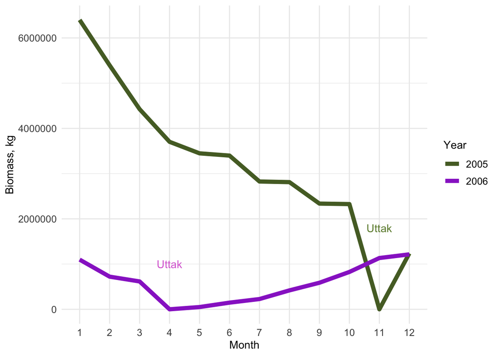

```r
biom_change0506 <- data.frame(
  year = rep(c(2005, 2006), each = 12),
  month = rep(c(1:12), 2),
  salmon = c(
    unname(unlist(biomass_0518[1, c(6:17)])),
    unname(unlist(biomass_0518[61, c(6:17)]))
  )
)


ggplot(data = biom_change0506) +
  geom_line(aes(x = as.factor(month), y = salmon, color = as.factor(year), group = year), size = 2) +
  labs(x = "Month",
       y = "Biomass, kg") +
  scale_color_manual(values = c("darkolivegreen", "darkorchid"), name = "Year") +
      theme_minimal() +
  theme(
    axis.text = element_text(size = 10),
    legend.text = element_text(size = 10)
  ) +
  annotate("text", x = 4, y = 1000000, label = "Uttak", color = "orchid", face = "bold") +
  annotate("text", x = 11, y = 1800000, label = "Uttak", color = "darkolivegreen4", face = "bold")
```

Which municipalities did not have aquaculture?

```r
anti_join(municip, biomass_0518[,c(4,5)], municip, by = c("Komnum"="KOMMUNENR")) %>%
  arrange(Name) %>%
  filter(Name != "NonCoast") %>%
  datatable()
```

|  | Komnum | Name | Kid |
| --- | --- | --- | --- |
| 1 | 1871 | Andoy | 40 |
| 2 | 2024 | Berlevag | 77 |
| 3 | 1832 | Hemnes | 14 |
| 4 | 1924 | Malselv | 50 |
| 5 | 2020 | Porsanger | 74 |
| 6 | 1856 | Rost | 31 |
| 7 | 2025 | Tana | 78 |
| 8 | 2003 | Vadso | 66 |
| 9 | 1857 | Vaeroy | 32 |
| 10 | 2002 | Vardo | 65 |

## 2.3 Pre-clean uttak (executed fish) table

```r
uttak_prep <- uttak_0518 %>%
  clean_names() %>%
  rename(year = aar) %>%
  select(-c(fylkesnr, fylke, kommune))
```

## 2.4 Pre-clean tap (lost fish) table and convert to kg

```r
utkast_prep <- tap_0518 %>%
  clean_names() %>%
  rename(year = aar) %>%
  select(-c(fylkesnr, fylke, kommune,tap_d_dfisk, tap_r_mming, tap_annet)) %>%
  mutate(lost_final_kg = tap_utkast*6)
```

## 2.5 Pre-clean feed table

```r
feed_prep <- feed_0518 %>%
  clean_names() %>%
  rename(year = aar) %>%
  select(-c(fylkesnr, fylke, kommune))
```